# Rfssa: An R Package for Functional Singular Spectrum Analysis

#### Example: Creating `funts` objects for MFTS

The second example considered two collection of images where each image is drawn from a region southeast of the city of Jambi, Indonesia located between latitudes of $1.666792^{\circ}$ S - $1.598042^{\circ}$ S and longitudes of $103.608963^{\circ}$ E - $103.677742^{\circ}$ E. The images were recorded using the MODerate Resolution Imaging Spectroradiometer (MODIS) Terra satellite with a resolution of 250 meters every 16 days starting from February 18, 2000 and ending July 28, 2019. The output of each image is the normalized difference vegetation index (NDVI) which is used to quantify how much vegetation is present and enhanced vegetation index (EVI). The NDVI values closer to one being indicative of more vegetation and values closer to zero indicate less vegetation (see Haghbin et al. 2021 for more details). The following code can be used to load the data, define a `funts` object for a MFTS, slice the `funts` object to select a specific variable (here NDVI), and plot the smoothed images over time in an animation, that a snapshot is given in Figure @ref(fig:figndvi-image).

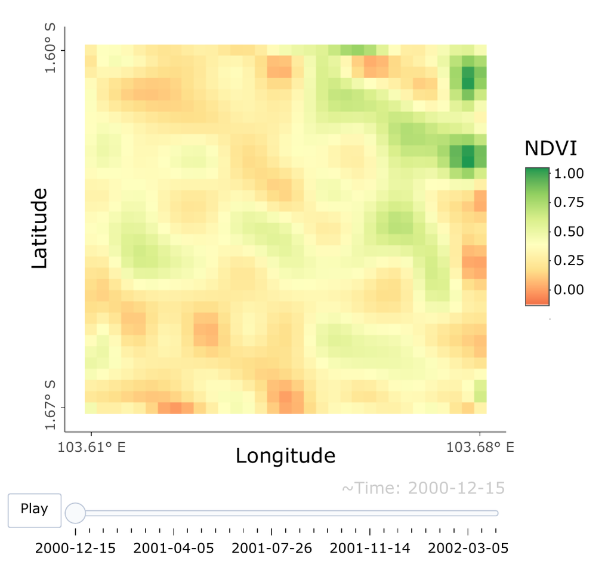

An NDVI snapshot from the city of Jambi, Indonesia.

```r
# Load the Jambi dataset
Jambi <- loadJambiData()

# Extract NDVI and EVI array data
NDVI <- Jambi$NDVI
EVI <- (Jambi$EVI)

# Create a list containing NDVI and EVI array data
Jambi_Data <- list(NDVI, EVI)

# Create a multivariate B-spline basis
require(fda)
bs2 <- create.bspline.basis(c(0, 1), 13)
bs2d <- list(bs2, bs2)
bsmv <- list(bs2d, bs2d)

# Create a funts object
Y_J <- funts(X = Jambi_Data,
    basisobj = bsmv,
    start = as.Date("2000-02-18"), end = as.Date("2019-07-28"),
    vnames = c("NDVI", "EVI"), tname = "Date",
    dnames = list(c("Latitude", "Longitude"), c("Latitude", "Longitude")))

# Create a Plotly-based visualization of the NDVI Image
plotly_funts(Y_J[, 1],
    main = "NDVI Image (Jambi)",
    xticklabels = list(c("103.61\u00B0 E", "103.68\u00B0 E")),
    yticklabels = list(c("1.67\u00B0 S", "1.60\u00B0 S")),
    xticklocs = list(c(0, 1)),
    yticklocs = list(c(0, 1)),
    color_palette = "RdYlGn")
```

### The `fssa` Class

- `values:` A numeric vector of singular values.
- `L:` The specified window length.
- `N:` The length of the functional time series.
- `Y:` The original `funts` object.

The generic `plot(`$\cdot$`)` is developed for the `fssa` class to help the user make decisions on how to do the grouping stage of FSSA/MFSSA. This method, provides a complete set of visualization tools for the user to check the quality of the decomposition stage. These SSA-type plots encompass various types, each providing unique insights into the data:

- **`"values"`**: Plots the singular values (default).
- **`"paired"`**: Visualizes pairs of right singular vectors, which is particularly useful for detecting periodic components.
- **`"wcor"`**: Generates a plot of the W-correlation matrix for the reconstructed objects.
- **`"vectors"`**: Displays the right singular vectors, aiding in the detection of period length.
- **`"lcurves"`**: Showcases the left singular functions, assisting in period length detection.
- **`"lheats"`**: Heatmap plots of left singular functions are available, designed for `funts` variables observed over one or two-dimensional domains. These plots are valuable for identifying meaningful patterns.
- **`"periodogram"`**: Periodogram plots of the right singular vectors can be generated, which help detect the frequencies of oscillations in functional data.

While efforts have been made to align these plots in [**Rfsaa**](https://CRAN.R-project.org/package=Rfsaa) with the non-functional versions available in the [**Rsaa**](https://CRAN.R-project.org/package=Rsaa) package, there are some fundamental differences. Notably, `"lheats"` and `"lcurves"` are novel plot types introduced in the [**Rfssa**](https://CRAN.R-project.org/package=Rfssa) package for functional data. Additionally, `"paired"` and `"vectors"` types are developed based on the right singular vectors. All these plot types utilize the [**lattice**](https://CRAN.R-project.org/package=lattice) graphics engine. The following example codes generate these plots for the `Callcenter` dataset.

#### Example: performing decomposition stage of FSSA

In the rest of the paper, we will use the pre-generated `funts` class object datasets such as `Callcenter` which are included within the package. These ready-to-use datasets serve as practical examples and templates, allowing users to test the FSSA procedure without the need to start from scratch with data preprocessing. As mentioned previously, our approach involves performing FSSA with a lag window of $L=28$. We then generate a variety of SSA-type plots, as illustrated in Figure @ref(fig:figcall-decomp), using the following code:

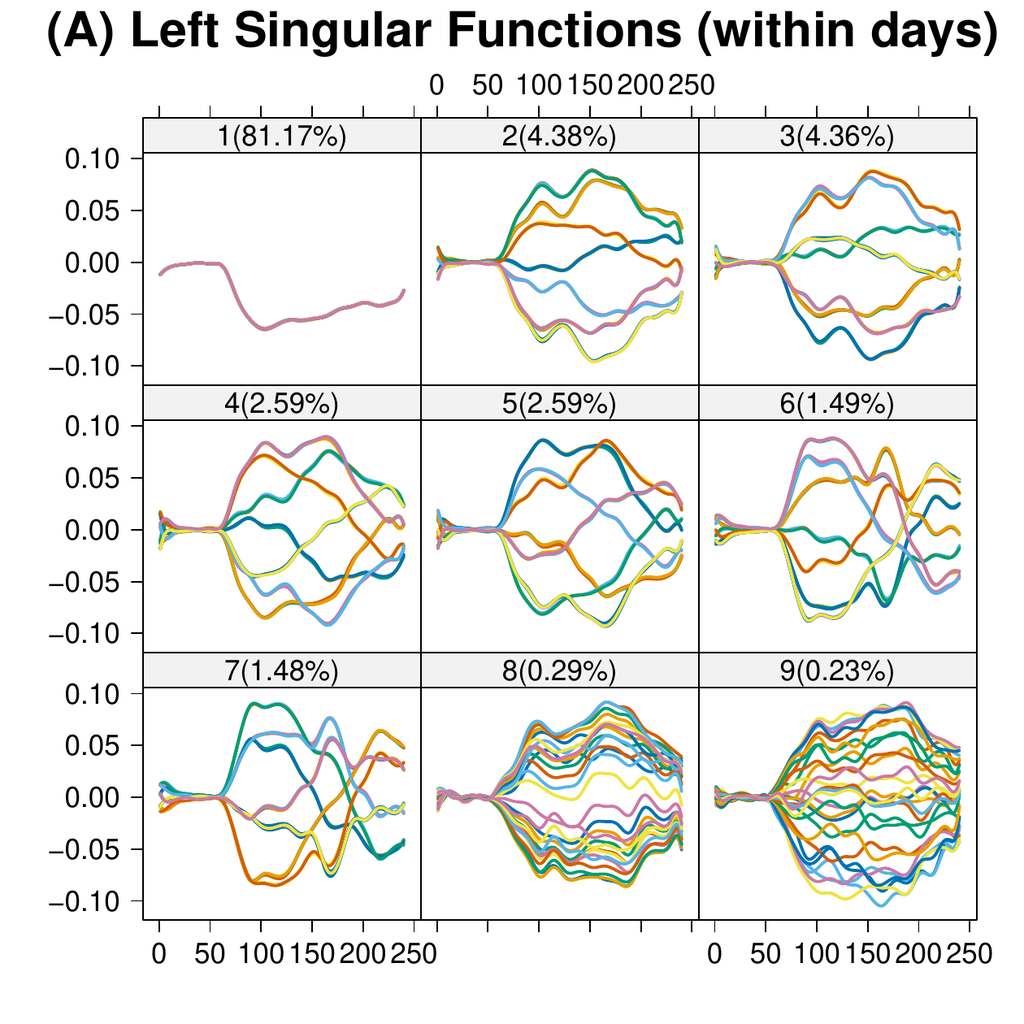

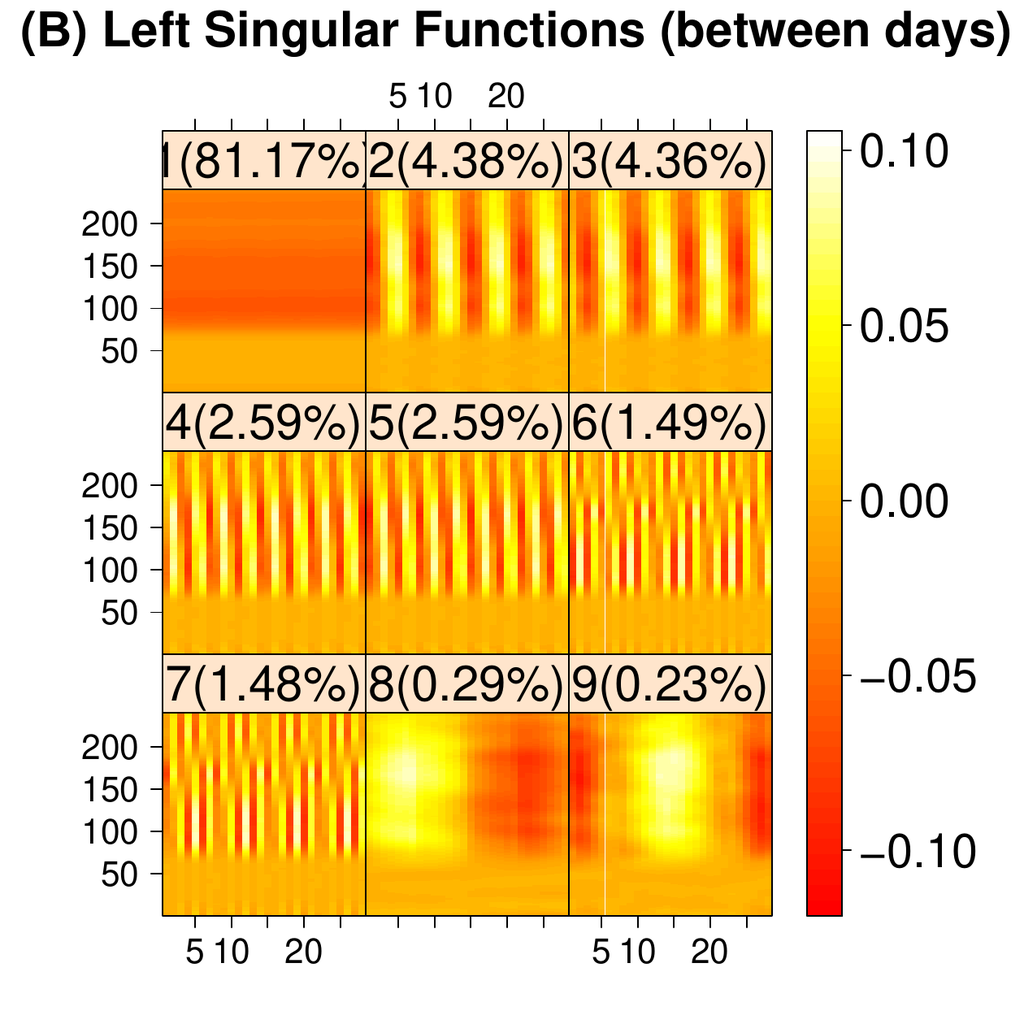

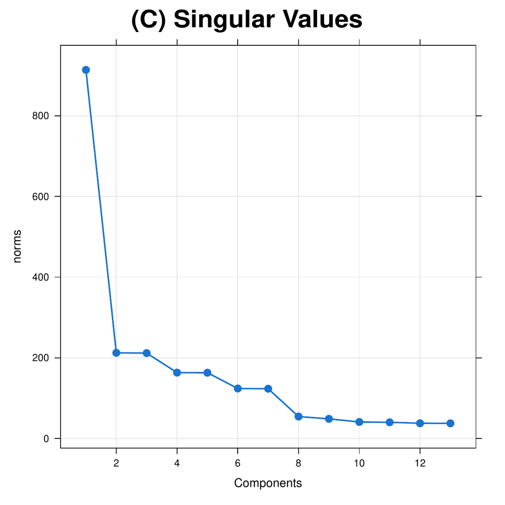

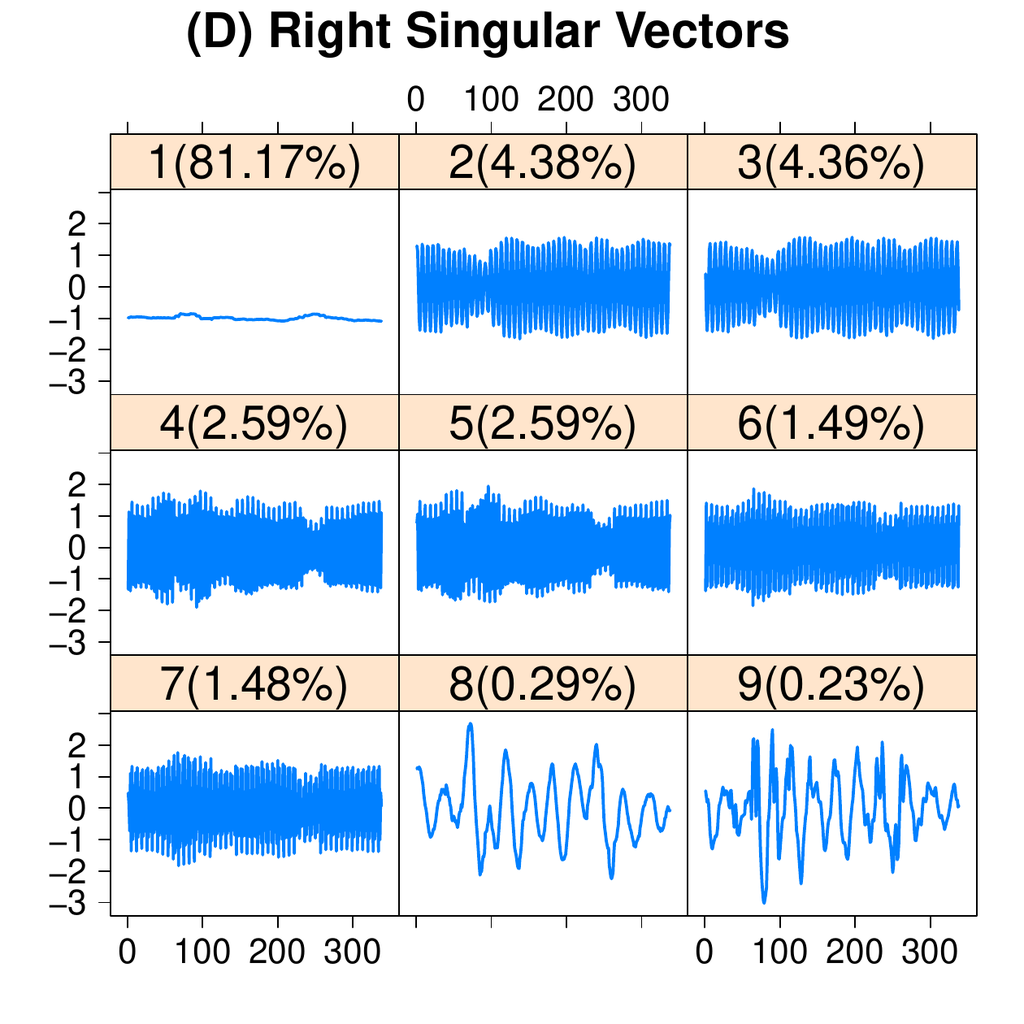

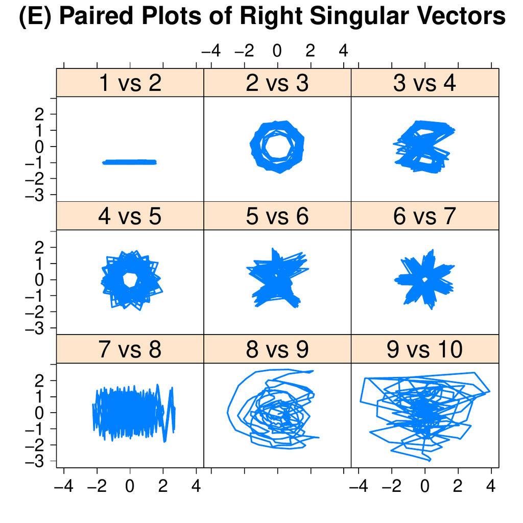

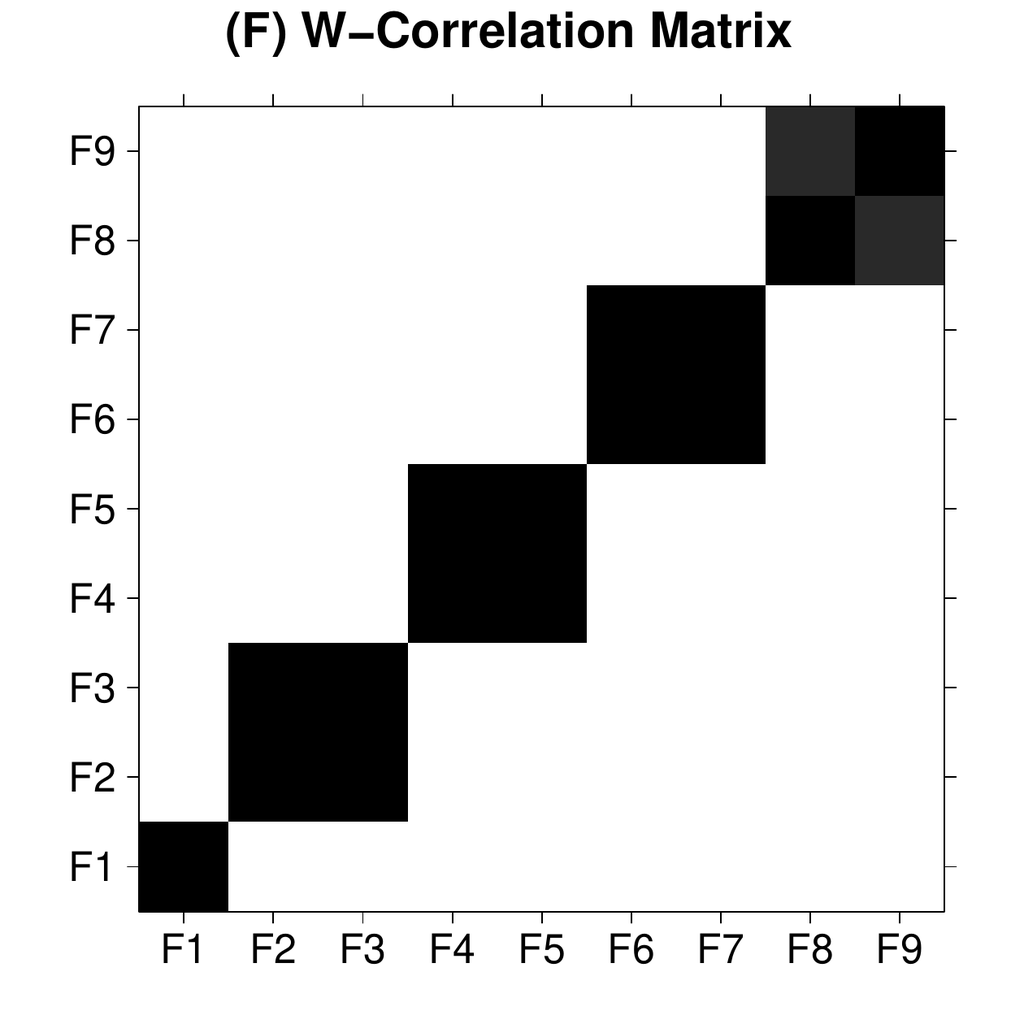

(A): Line plot of the left singular functions, used to identify periodic and trend components; (B): Heatmap of the left singular functions; (C): Scree plot of the singular values often used for grouping; (D): Right singular vectors, used to identify periodic and trend components; (E): Paired plots of the right singular vectors, used for grouping and identifying periodicity in the FTS; (F): Weighted correlation (W-correlation) matrix used for grouping.

```r
# Load the Callcenter dataset
data("Callcenter")

# Perform FSSA:
fssa_results <- fssa(Callcenter, L = 28)

# FSSA plots:
plot(fssa_results, d = 9, type = "lcurves",
    main = "(A) Left Singular Functions (within days)")
plot(fssa_results, d = 9, type = "lheats",
    main = "(B) Left Singular Functions (between days)")
plot(fssa_results, d = 13, main = "(C) Singular Values")
plot(fssa_results, d = 9, type = "vectors",
    main = "(D) Right Singular Vectors")
plot(fssa_results, d = 10, type = "paired",
    main = "(E) Paired Plots of Right Singular Vectors")
plot(fssa_results, d = 9, type = "wcor",
    main = "(F) W-Correlation Matrix")
```

## Reconstruction and forecasting

After obtaining an object of class `fssa`, the user may then choose to perform reconstruction using the `freconstruct(`$\cdot$`)` function or perform forecasting using `fforecast(`$\cdot$`)`. The reconstruction and forecasting functions both return a list of `funts` objects with length $m$ (number of groups). We note that even though it is common to perform forecasting using a combination of groups that best reconstructs the original signal, the user may try to forecast using several different combinations of groups.

### Reconstruction

```r
# Define groups and their labels
groups <- list(1, 2:3, 4:5, 6:7, 1:7)
group_labels <- c("(B) First Group",
    "(C) Second Group",
    "(D) Third Group",
    "(E) Fourth Group",
    "(F) Extracted Signal")

# Perform FSSA‌ reconstruction
reconstructed_data  <- freconstruct(fssa_results, groups)

# Create and visualize plots
for (i in 1:length(groups)) {
  print(plotly_funts(reconstructed_data[[i]], main = group_labels[i],
        xticklocs = xtlab, xticklabels = xtloc))
}
```

[output not shown]

### The `fforecast` Class

As previously mentioned, in addition to performing reconstruction of the FTS, the package offers the capability to perform forecasting using an object of class `fssa`. The constructor for this class, i.e., the `fforecast(`$\cdot$`)` function, accepts the following arguments:

- `U`: An object of class `fssa` holding the decomposition.
- `groups`: A list of numeric vectors where each vector is used for reconstruction and forecasting.
- `len`: An integer representing the desired length of the forecasted FTS.
- `method`: A character string specifying the type of forecasting to perform, with options including:
  - "recurrent" for FSSA R-forecasting.
  - "vector" for FSSA V-forecasting.
- `only.new`: A logical argument, when set to `TRUE`, returns only the forecasted FTS, otherwise the entire FTS is returned.

The `fforecast(`$\cdot$`)` function returns an S3 class named `fforecast`, which has been introduced to encapsulate the output of the function. This class is designed to provide a more organized and intuitive structure for handling FTS data. The `fforecast` class includes the following attributes:

- `original_funts`: This attribute stores the original FTS object, allowing users to maintain a clear reference to the original data.
- `predicted_time`: Stores the forecast time index.
- `groups`: Contains a list of numeric vectors, where each vector includes indices of elementary components of a group used for reconstruction and forecasting.
- `method`: A character string specifying the type of forecasting performed.

To streamline user interactions further, we have developed a `print(`$\cdot$`)` method for the `fforecast` class, making it more convenient to view and assess forecasted FTS data. To illustrate these enhancements, consider the continuous of Callcenter data example in the following:

```r
# Perform FSSA R-forecasting
pr_R <- fforecast(U = fssa_results, groups = c(1:3), len = 14, method = "recurrent")
# Perform FSSA V-forecasting
pr_V <- fforecast(U = fssa_results, groups = list(1,1:7), len = 14, method = "vector",
    only.new = FALSE)

plot(pr_R, main = 'R-Forecast (only.new = TRUE)')
plot(pr_V, main = 'V-Forecast (only.new = FALSE)')
print(pr_V)

# FSSA Forecast (fforecast) class:
# Groups: List of 2
# : num 1
# : int [1:7] 1 2 3 4 5 6 7
# Prediction method:  vector
# Predicted series length:  14
# Predicted time:  Date[1:14], format: "2000-01-01" "2000-01-02" ...

# ---------The original series-----------
# Functional time series (funts) object:
# Number of variables:  1
# Lenght:  365
# Start:  10592
# End:  10956
# Time:  Date[1:365], format: "1999-01-01" "1999-01-02" "1999-01-03"  ...
```

The resulted figure are shown in the Figure @ref(fig:figforecast).

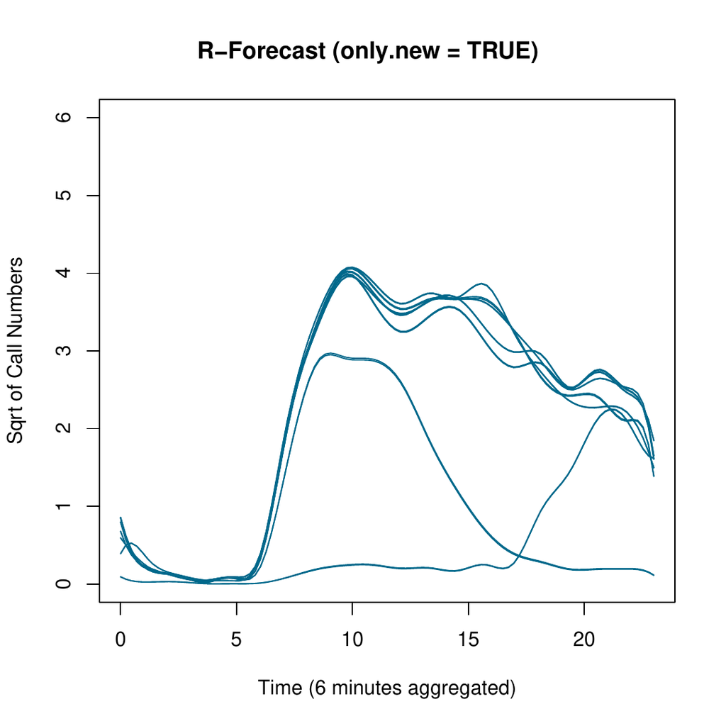

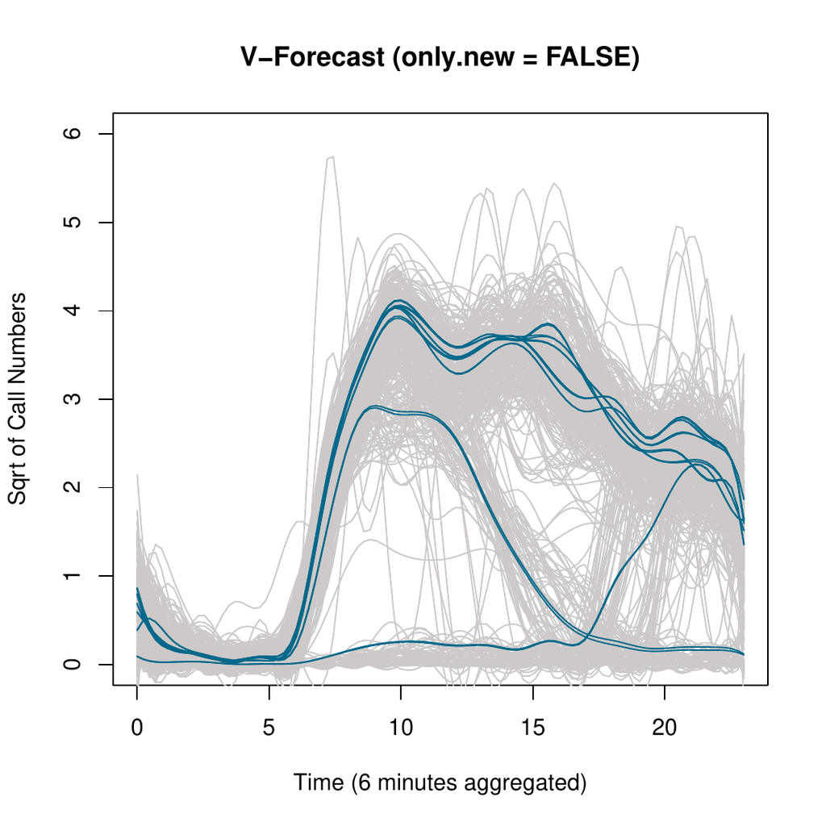

plot($\cdot$) method of fforecast class.

```r
# Define the data length
N <- Callcenter$N
U1 <- fssa(Callcenter[1:(N-7)], 28)

# Perform recurrent forecasting using FSSA
fore_R = fforecast(U1, groups = list(1:7), method = "recurrent", len = 7)[[1]]

# Perform vector forecasting using FSSA
fore_V = fforecast(U1, groups = list(1:7), method = "vector", len = 7)[[1]]

# Extract the true call data
true_call <- Callcenter[(N-7+1):N]

# Define weekdays and colors
wd <- c('Sunday', 'Monday', 'Tuesday', 'Wednesday','Thursday', 'Friday', 'Saturday')
clrs <- c("black", "turquoise4", "darkorange")
argvals <- seq(0, 23, length.out = 100)
par(mfrow = c(1,7), mar = c(0.2, 0.2, 2, 0.2))

# Iterate over the days of the week
for(i in 1:7) {
    plot(true_call[i], col = clrs[1], ylim = c(0, 5.3),
        lty = 3, yaxt = "n", xaxt = "n", main = wd[i])
    plot(fore_R[i], col = clrs[2], lty = 2, add = TRUE)
    plot(fore_V[i], col = clrs[3], lty = 5, add = TRUE)
}
legend("top", c("Original", "R-forecasting", "V-forecasting"), col = clrs,
    lty = c(3, 2, 5))
```

[output not shown]

More information on these results may be found in the associated literature of (Haghbin et al. 2021) and (J. Trinka et al. 2023).

## A shiny application

The [**Rfssa**](https://CRAN.R-project.org/package=Rfssa) package contains shiny-apps for both FSSA and MFSSA methods. Those shiny-apps can be called using the `launchApp(`$\cdot$`)` function, and also available in http://sctc.mscs.mu.edu/fssa.htm and http://sctc.mscs.mu.edu/mfssa.htm. Here we present the features of the MFSSA app, since the FSSA app would be a special case of that. MFSSA shiny-app was developed to visualize and extract the information related to MFTS in a non-parametric framework. The proposed shiny-app provides a friendly GUI for user to implement the [**Rfssa**](https://CRAN.R-project.org/package=Rfssa) functionalities and even compare the results with the non-functional version ([**Rssa**](https://CRAN.R-project.org/package=Rssa)).

Figure @ref(fig:figshiny) provides a snapshot of the features available in MFSSA shiny-app. In the top of the side bar panel, user may specify the basis functions (B-spline or Fourier) and the associated degrees of freedom to represent the `funts` object. Those basis functions can be visualized in sub-panel ‘Basis Functions’ under the main panel. The remaining inputs in the side bar will be used in other sub-panels. Specifically ‘Groups’ is an input box for the third step of the MFSSA algorithm. Each group is specified via a vector (e.g. ‘`c(1,2,4)`’ or ‘`1:3`’) and separated from other groups with a comma (‘,’). The slider ‘d’ is used to specify the dimensions used in MFSSA (scree, W-correlation, paired, singular vectors & functions, and periodogram plots). The check-box (a) ‘Demean’ is used to subtract the mean to obtain mean-zero functions; (b) ‘Dbl Range’ is used to extend the y-axis to cover all potential mirror functions (e.g. sometime FPCs may get multiply by a negative sign); and (c) ‘Univ. FSSA’ to compare the MFSSA results with marginal FSSA ones respectively. The ‘Win.L.’ slider specify the window lengths for the MSSA and the MFSSA. The ‘run M(F)SSA’ button is used to run MSSA and MFSSA using the specified parameters for the given dataset. In general, for the side bar, the top inputs (above the red line) are mostly to describe the basis functions. The bottom inputs (below the red line) are used to specify SSA and FSSA parameters.

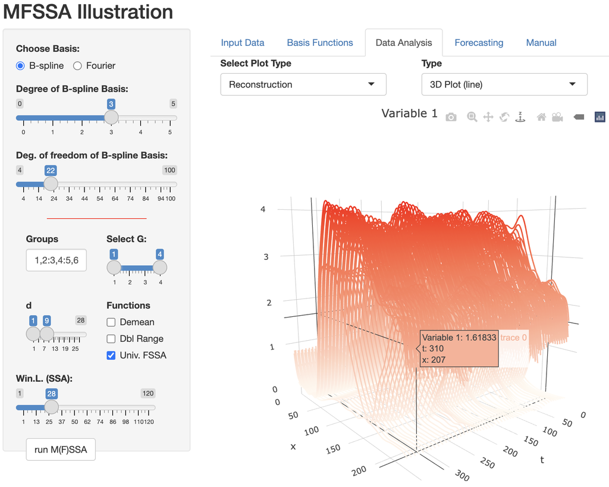

Snapshot of the MFSSA shiny-app

The main panel includes five sub-panels. Here we briefly describe the features in each of these sub-panels:

- ‘Input Data’: In this sub-panel user can either (a) use the functional datasets available in the [**Rfssa**](https://CRAN.R-project.org/package=Rfssa) package (e.g, `Callcenter` data or remote sensing datasets); (b) simulate MFTS (see Haghbin et al. 2021 for details on simulation setup); or (c) upload any arbitrary FTS matrix (where FTS are given in common grid-points and are represented in the columns of the data matrix) to provide the dataset and then analyze it.
- ‘Basis Functions’: As described before we illustrate the basis functions selected by user in this sub-panel.
- ‘Data Analysis’: In this sub-panel user can call variety of tools to
  - visualize the MFTS.
  - obtain the optimal number of basis functions based on the GCV criteria.
  - select variety of outputs under MSSA and MFSSA, that includes scree plot, W-correlation plot, paired plots, singular vectors plots, periodogram plots, singular functions (heat or regular plots), and reconstruction of FTS using different type of plots (heat, regular, 3Dline and 3Dsurface). An example of the 3Dline reconstruction plot for the `Callcenter` data is given in Figure @ref(fig:figshiny).
- ‘Forecasting’: This sub-panel would be accessible after user runs the MFSSA procedure, and it includes the functionalities of R-forecasting and V-forecasting algorithms.
- ‘Manual’: This sub-panel provides a brief instruction manual to use the MFSSA shiny-app.

## Summary and conclusion

In summary, **Rfssa** is a pioneering package that brings the power of SSA to the realm of functional time series, offering novel techniques for decomposition, reconstruction, multivariate analysis, and functional forecasting. Its flexible data representation and functional context for SSA make it a valuable addition to the CRAN ecosystem, providing unique capabilities not readily available in other packages.

Notably, the package offers extensive capabilities for analyzing FTS/MFTS data, allowing joint analysis of smoothed curves and image data across different dimensional domains. The implementations of the methodologies in the package have been optimized for speed by leveraging the functionalities of [**RcppEigen**](https://CRAN.R-project.org/package=RcppEigen) and [**RSpectra**](https://CRAN.R-project.org/package=RSpectra) R packages, along with custom C++ code. By utilizing the [**Rfssa**](https://CRAN.R-project.org/package=Rfssa) package, researchers and practitioners can easily apply advanced FSSA-based techniques to their data, yielding informative results that can significantly enhance decision-making across various applied domains. The intuitive nature and computational efficiency of the package make it a valuable asset for the FTS analysis toolkit.

## Acknowledgments

The authors would like to express their sincere gratitude to the anonymous reviewers for their valuable feedback and constructive comments, which greatly contributed to the improvement of this work. Additionally, we would like to acknowledge the significant contributions of Dr. S. Morteza Najibi during the development stages of the first version of the [**Rfssa**](https://CRAN.R-project.org/package=Rfssa) package.

Bouveyron, Charles. 2021. *funFEM: Clustering in the Discriminative Functional Subspace*. https://CRAN.R-project.org/package=funFEM.

Carvalho, Miguel de, and Gabriel Martos. 2020. *ASSA: Applied Singular Spectrum Analysis*. https://CRAN.R-project.org/package=ASSA.

Carvalho, Miguel de, and António Rua. 2017. “Real-Time Nowcasting the US Output Gap: Singular Spectrum Analysis at Work.” *International Journal of Forecasting* 33 (1): 185–98.

Febrero-Bandle, Manuel, and Manuel Oviedo de la Fuente. 2012. “Statistical Computing in Functional Data Analysis: The r Package .” *Journal of Statistical Software* 51 (4): 1–28. https://doi.org/10.18637/jss.v051.i04.

Gajardo, Alvaro, Satarupa Bhattacharjee, Cody Carroll, Yaqing Chen, Xiongtao Dai, Jianing Fan, Pantelis Z. Hadjipantelis, et al. 2022. *Fdapace: Functional Data Analysis and Empirical Dynamics*. https://CRAN.R-project.org/package=fdapace.

Goldsmith, Jeff, Fabian Scheipl, Lei Huang, Julia Wrobel, Chongzhi Di, Jonathan Gellar, Jaroslaw Harezlak, et al. 2023. *Refund: Regression with Functional Data*. https://CRAN.R-project.org/package=refund.

Golyandina, Nina, Anton Korobeynikov, Alex Shlemov, and Konstantin Usevich. 2015. “Multivariate and 2D extensions of the Rssa package.” *Journal of Statistical Software* 67 (2): 1–78. https://doi.org/10.18637/jss.v067.i02.

Golyandina, Nina, Anton Korobeynikov, and Anatoly Zhigljavsky. 2018. *Singular Spectrum Analysis with r*. Springer Berlin Heidelberg.

Golyandina, Nina, Vladimir Nekrutkin, and Anatoly A Zhigljavsky. 2001. *Analysis of Time Series Structure: SSA and Related Techniques*. Chapman; Hall/CRC, Boca Raton, FL.

Golyandina, Nina, and Anatoly Zhigljavsky. 2013. *Singular Spectrum Analysis for Time Series*. Springer Science & Business Media, Berlin, Heidelberg.

Haghbin, Hossein, Seyed Morteza Najibi, Rahim Mahmoudvand, Jordan Trinka, and Mehdi Maadooliat. 2021. “Functional Singular Spectrum Analysis.” *Stat*, e330. https://doi.org/https://doi.org/10.1002/sta4.330.

Haghbin, Hossein, Jordan Trinka, Seyed Morteza Najibi, and Mehdi Maadooliat. 2023. *Rfssa: Functional Singular Spectrum Analysis*. https://CRAN.R-project.org/package=Rfssa.

Happ-Kurz, Clara. 2020. “Object-Oriented Software for Functional Data.” *Journal of Statistical Software* 93 (5): 1–38. https://doi.org/10.18637/jss.v093.i05.

Hassani, Hossein, and Rahim Mahmoudvand. 2013. “Multivariate Singular Spectrum Analysis: A General View and New Vector Forecasting Approach.” *International Journal of Energy and Statistics* 01 (01): 55–83. https://doi.org/10.1142/S2335680413500051.

Horn, Roger A., and Charles R. Johnson. 2012. *Matrix Analysis*. Cambridge University Press.

Hyndman, Rob, and Han Lin Shang. 2023. *ftsa: Functional Time Series Analysis*. https://CRAN.R-project.org/package=ftsa.

Maadooliat, Mehdi, Jianhua Z Huang, and Jianhua Hu. 2015. “Integrating Data Transformation in Principal Components Analysis.” *Journal of Computational and Graphical Statistics* 24 (1): 84–103.

Ramsay, J. O., and B. W. Silverman. 2005. *Functional Data Analysis*. Springer Series in Statistics. New York, NY. http://0-search.ebscohost.com.libus.csd.mu.edu/login.aspx?direct=true&db=cat06952a&AN=mul.b2395232&site=eds-live.

Ramsay, J. O., Hadley Wickham, Spencer Graves, and Giles Hooker. 2023. *fda: Functional Data Analysis*. https://CRAN.R-project.org/package=fda.

Shang, Han Lin, and Rob Hyndman. 2022. *Rainbow: Rainbow Plots, Bagplots and Boxplots for Functional Data*. https://CRAN.R-project.org/package=rainbow.

Tavakoli, Shahin. 2015. *ftsspec: Spectral Density Estimation and Comparison for Functional Time Series*. https://CRAN.R-project.org/package=ftsspec.

Trinka, J., H. Haghbin, H. L. Shang, and M. Maadooliat. 2023. “Functional Time Series Forecasting: Functional Singular Spectrum Analysis Approaches.” *Stat* 12 (1): e621. https://doi.org/10.1002/sta4.621.

Trinka, Jordan, Hossein Haghbin, and Mehdi Maadooliat. 2022. “Multivariate Functional Singular Spectrum Analysis: A Nonparametric Approach for Analyzing Multivariate Functional Time Series.” In *Innovations in Multivariate Statistical Modeling: Navigating Theoretical and Multidisciplinary Domains*, 187–221. Springer.